# Data-Related Jobs Salary Analysis

William Lin

2023-12-02

```r
library(dplyr)
```

```r
library(tidyr)
library(ggplot2)
```

Key performance indicator (KPI): Paid Wage Per Year

Team ANOVA will be analyzing the salary dataset for our DS311 project. The salary dataset displays records from 167,278 Labor Condition Applications (which include H1-B and other specialty visas) and the permanent resident applications from 2008 to 2015. The dataset intends to track who is entering and leaving the US government for work-related reasons. Each applicant provides information based on their work location, paid/prevailing wages, and their selected job position. Within this dataset, there are 25 variables with 2 extra non-meaningful variables. Several goals of the project include comparing prevailing wages and paid wages, comparing wages by job title, comparing wages by location, and more.

## Salary data

```r
salary <- read.csv("/Users/linw/Desktop/Team-Anova-Project/Will_WIP/salary_data_states.csv")
```

```r
# Inspecting the data
dim(salary)
```

```
## [1] 167278     27
```

```r
head(salary)
```

```
##          CASE_NUMBER CASE_STATUS CASE_RECEIVED_DATE DECISION_DATE
## 1 I-200-14073-248840      denied          3/14/2014     3/21/2014
## 2      A-15061-55212      denied          3/19/2015     3/19/2015
## 3 I-200-13256-001092      denied          9/13/2013     9/23/2013
## 4 I-200-14087-353657      denied          3/28/2014      4/7/2014
## 5 I-203-14259-128844      denied          9/16/2014     9/23/2014
## 6 I-200-14092-483272      denied           4/2/2014      4/9/2014
##                                        EMPLOYER_NAME PREVAILING_WAGE_SUBMITTED
## 1                ADVANCED TECHNOLOGY GROUP USA, INC.                   6217100
## 2                     SAN FRANCISCO STATE UNIVERSITY                   5067600
## 3                                    CAROUSEL SCHOOL                   4947000
## 4 HARLINGEN CONSOLIDATED INDEPENDENT SCHOOL DISTRICT                    251052
## 5                        SIGNAL SCIENCES CORPORATION                     84573
## 6                                 CAPGEMINI U.S. LLC                    113610
##   PREVAILING_WAGE_SUBMITTED_UNIT PAID_WAGE_SUBMITTED PAID_WAGE_SUBMITTED_UNIT
```

[output cut: 55 more lines]

```r
tail(salary)
```

```
##               CASE_NUMBER         CASE_STATUS CASE_RECEIVED_DATE DECISION_DATE
## 167273 I-200-12241-762461 certified-withdrawn          8/28/2012      6/6/2013
## 167274 I-200-12241-209885 certified-withdrawn          8/28/2012      6/6/2013
## 167275 I-200-11305-143547              denied          11/1/2011     11/3/2011
## 167276 I-200-11313-833007           certified          11/9/2011    11/16/2011
## 167277 I-200-11312-798611              denied          11/8/2011    11/15/2011
## 167278 I-200-11297-523711              denied         10/24/2011    10/26/2011
##                                   EMPLOYER_NAME PREVAILING_WAGE_SUBMITTED
## 167273 CHINESE BIBLE CHURCH INTERNATIONAL, INC.                      5.05
## 167274 CHINESE BIBLE CHURCH INTERNATIONAL, INC.                      5.05
## 167275 CHINESE BIBLE CHURCH INTERNATIONAL, INC.                      5.05
## 167276 CHINESE BIBLE CHURCH INTERNATIONAL, INC.                      5.05
## 167277 CHINESE BIBLE CHURCH INTERNATIONAL, INC.                      5.05
## 167278 CHINESE BIBLE CHURCH INTERNATIONAL, INC.                      5.05
##        PREVAILING_WAGE_SUBMITTED_UNIT PAID_WAGE_SUBMITTED
```

[output cut: 62 more lines]

The dataset has 167,278 observations and 27 columns. Two variables are extras or non-meaningful: the initials/codes of U.S. states/territories, and the variable order seems to be an index from a previous uncleaned version of the dataset.

## Summary statistics

```r
summary(salary$PREVAILING_WAGE_PER_YEAR)
```

```
##    Min. 1st Qu.  Median    Mean 3rd Qu.    Max.    NA's
##   10504   56880   70928   74275   90459  320000      68
```

```r
summary(salary$PAID_WAGE_PER_YEAR)
```

```
##    Min. 1st Qu.  Median    Mean 3rd Qu.    Max.
##   10500   63000   78600   85533  100006 2500000
```

```r
paid_wage_sum_stats <- salary %>%
  summarize(Variable = "Paid Wage Per Year ($)",
            Min = min(PAID_WAGE_PER_YEAR),
            Q25 = quantile(PAID_WAGE_PER_YEAR, 0.25),
            Median = median(PAID_WAGE_PER_YEAR),
            Mean = mean(PAID_WAGE_PER_YEAR),
            Q75 = quantile(PAID_WAGE_PER_YEAR, 0.75),
            Q99 = quantile(PAID_WAGE_PER_YEAR, 0.99),
            Max = max(PAID_WAGE_PER_YEAR))

prev_wage_sum_stats <- salary %>%
  summarize(Variable = "Prevailing Wage Per Year ($)",
            Min = min(PREVAILING_WAGE_PER_YEAR, na.rm=T),
            Q25 = quantile(PREVAILING_WAGE_PER_YEAR, 0.25, na.rm=T),
            Median = median(PREVAILING_WAGE_PER_YEAR, na.rm=T),
            Mean = mean(PREVAILING_WAGE_PER_YEAR, na.rm=T),
            Q75 = quantile(PREVAILING_WAGE_PER_YEAR, 0.75, na.rm=T),
            Q99 = quantile(PREVAILING_WAGE_PER_YEAR, 0.99, na.rm=T),
            Max = max(PREVAILING_WAGE_PER_YEAR, na.rm=T))

paid_wage_sum_stats; prev_wage_sum_stats
```

```
##                 Variable   Min   Q25 Median     Mean    Q75   Q99     Max
## 1 Paid Wage Per Year ($) 10500 63000  78600 85532.77 100006 2e+05 2500000
```

```
##                       Variable   Min   Q25 Median     Mean   Q75      Q99
## 1 Prevailing Wage Per Year ($) 10504 56880  70928 74274.87 90459 139742.1
##      Max
## 1 320000
```

```r
sum_stats = bind_rows(paid_wage_sum_stats, prev_wage_sum_stats)
sum_stats
```

```
##                       Variable   Min   Q25 Median     Mean    Q75      Q99
## 1       Paid Wage Per Year ($) 10500 63000  78600 85532.77 100006 200000.0
## 2 Prevailing Wage Per Year ($) 10504 56880  70928 74274.87  90459 139742.1
##       Max
## 1 2500000
## 2  320000
```

The minimum, first quartile, median, third quartile, and maximum prevailing wage per year are as follows: $10,504, $56,880, $70,928, $90,459, and $320,000. The mean prevailing wage per year is $74274.86 with standard deviation $25356.24. The numerical summary for the paid wage per year is as follows: $10,500, $63,000, $78,600, $100,006, and $2,500,000. The mean paid wage per year is $85,532.77 with standard deviation $38738.47.

## Visualization of key quantitative variables

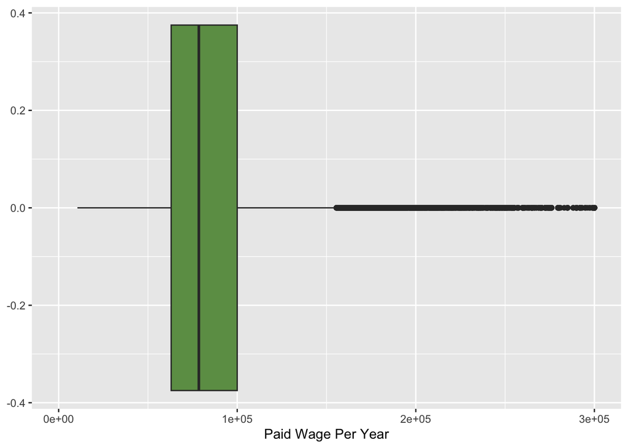

```r
ggplot(data=salary, aes(y=PAID_WAGE_PER_YEAR)) +
  geom_boxplot(fill = "#6c9c54") +
  coord_flip() +
  ylim(0, 300000) +
  ylab("Paid Wage Per Year")
```

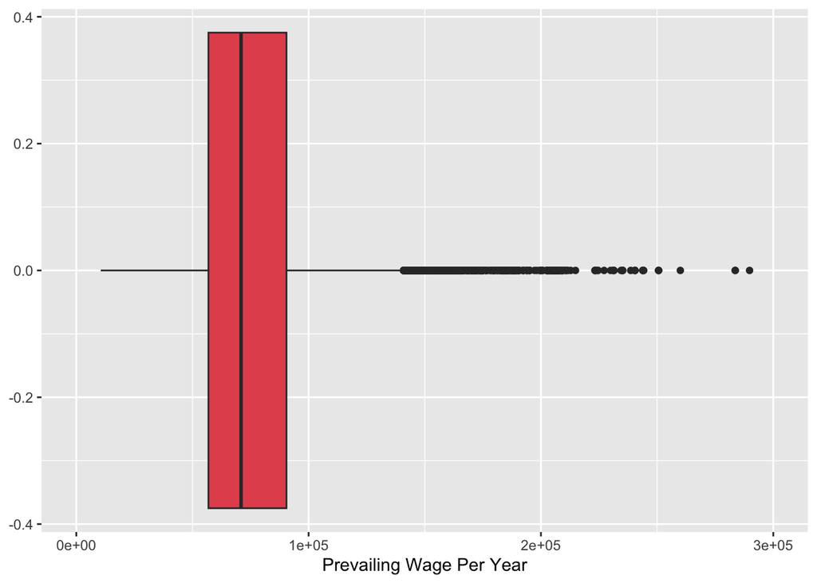

```r
ggplot(data=salary, aes(y=PREVAILING_WAGE_PER_YEAR)) +
  geom_boxplot(fill = "#e4545c") +
  coord_flip() +
  ylim(0, 300000) +
  ylab("Prevailing Wage Per Year")
```

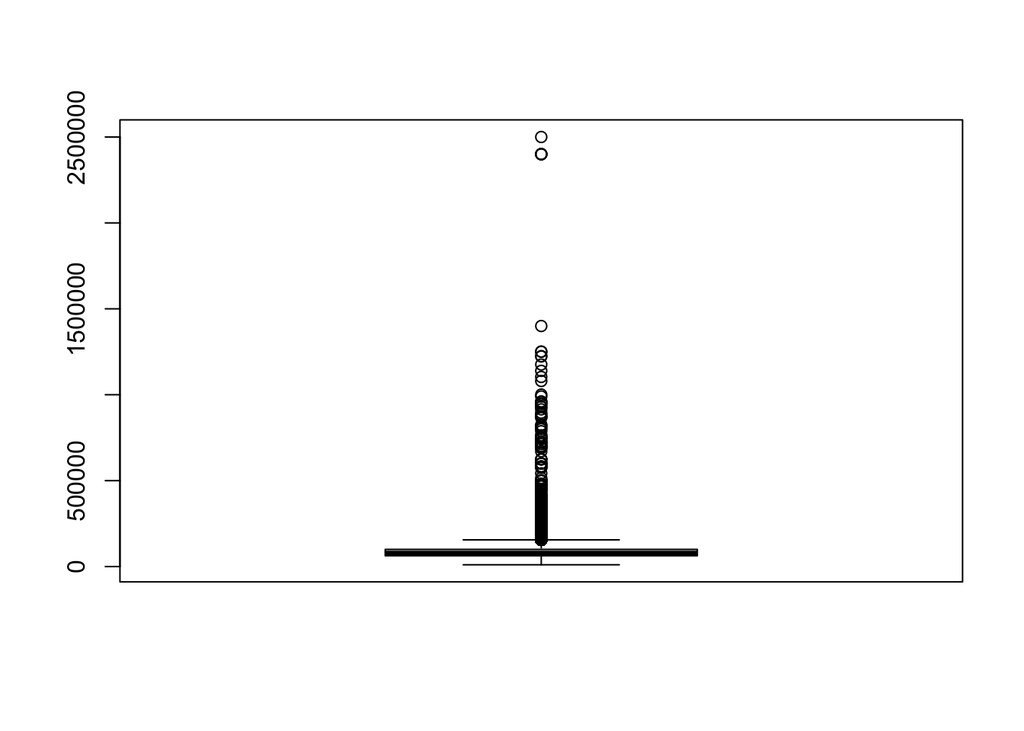

```r
# Before cleaning
boxplot(salary$PAID_WAGE_PER_YEAR)
```

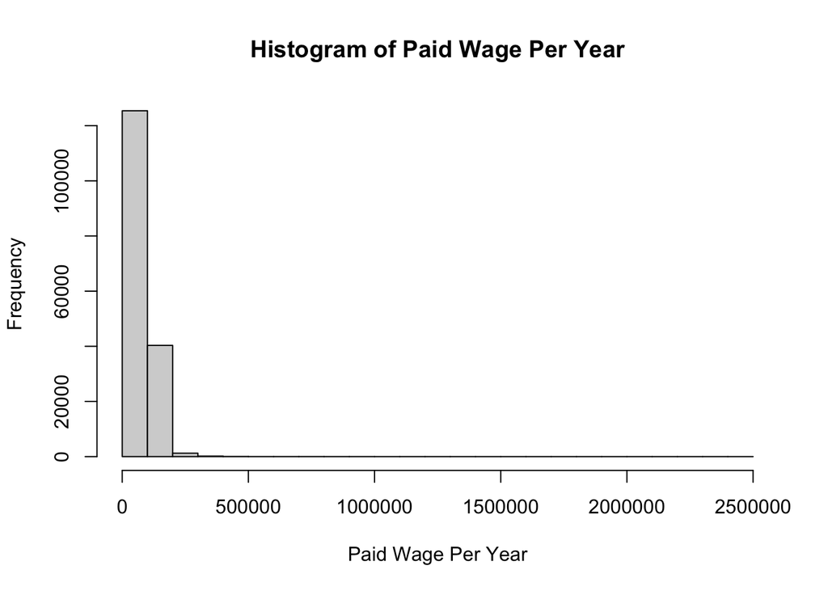

```r
hist(salary$PAID_WAGE_PER_YEAR,
     main='Histogram of Paid Wage Per Year',
     xlab='Paid Wage Per Year')
```

## How do offered salaries compare to the prevailing wage?

We create a new feature “PAY_DIFFERENCE”, which represents the difference between the paid wage per year and the prevailing wage per year.

```r
salary$PAY_DIFFERENCE = salary$PAID_WAGE_PER_YEAR - salary$PREVAILING_WAGE_PER_YEAR

# Summary stats: Difference in wage (paid vs. prevailing)
summary(salary$PAY_DIFFERENCE)
```

```
##    Min. 1st Qu.  Median    Mean 3rd Qu.    Max.    NA's
## -137900       0    3672   11256   13395 2307621      68
```

```r
# Summary stats for pay difference
pay_diff_sum_stats <- salary %>%
  summarize(Q001 = quantile(PAY_DIFFERENCE, 0.001,na.rm=T),
            Q25 = quantile(PAY_DIFFERENCE, 0.25,na.rm=T),
            Median = median(PAY_DIFFERENCE,na.rm=T),
            Mean = mean(PAY_DIFFERENCE,na.rm=T),
            Q75 = quantile(PAY_DIFFERENCE, 0.75,na.rm=T),
            Q95 = quantile(PAY_DIFFERENCE, 0.95,na.rm=T))
pay_diff_sum_stats
```

```
##        Q001 Q25 Median     Mean   Q75      Q95
## 1 -37675.36   0   3672 11255.48 13395 43630.04
```

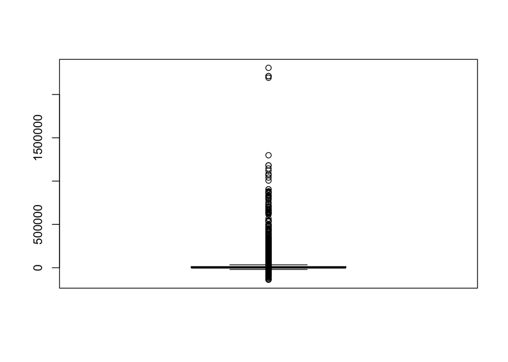

```r
# Boxplot in base R
boxplot(salary$PAY_DIFFERENCE)
```

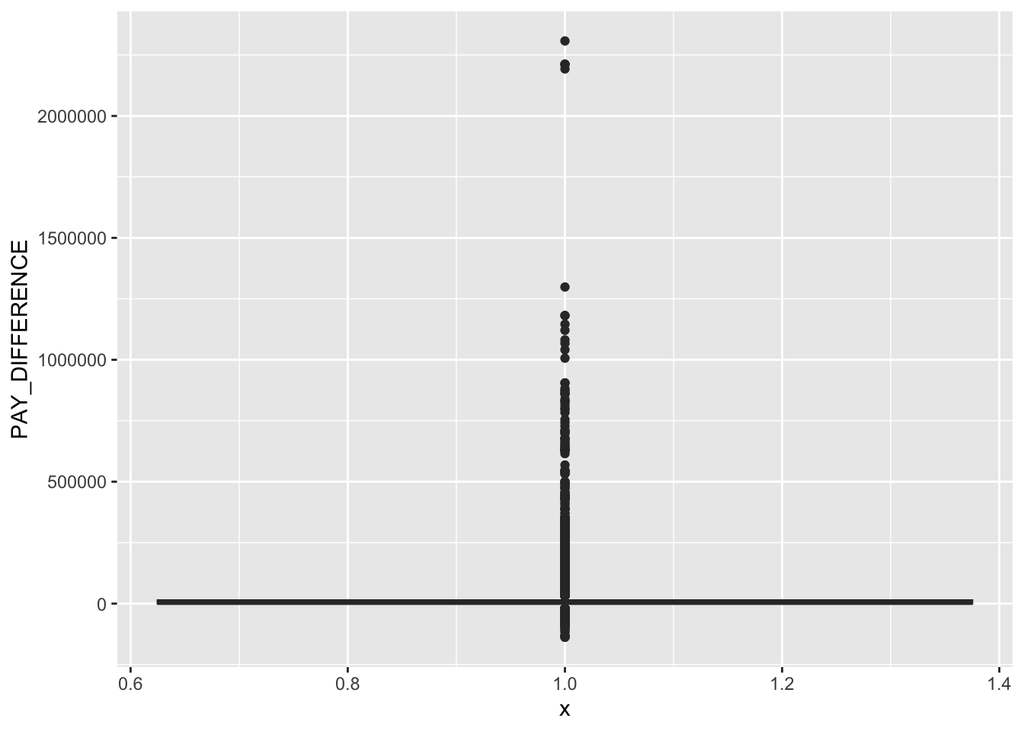

```r
# Create box plot with ggplot2
ggplot(data=salary, aes(y=PAY_DIFFERENCE, x=1)) + geom_boxplot()
```

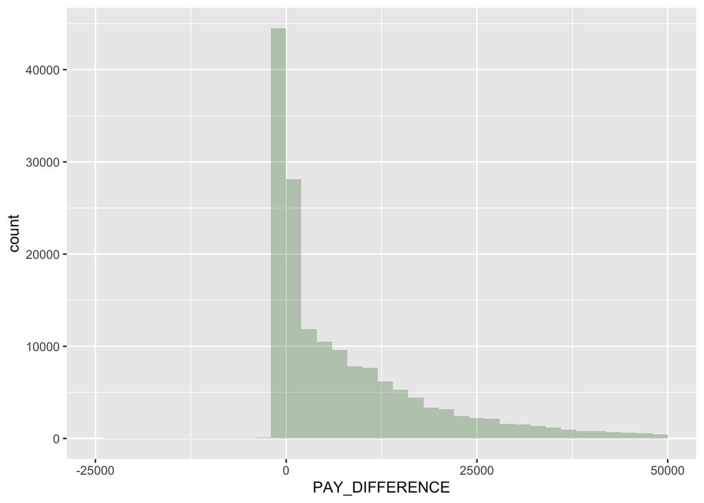

```r
# Histogram with ggplot2
ggplot(data=salary) + geom_histogram(aes(x=PAY_DIFFERENCE),fill="darkgreen", alpha=0.25, binwidth = 2000, boundary = 0) + xlim(-25000,50000)
```

- Are there job sub-categories that tend to get overpaid or under-paid?

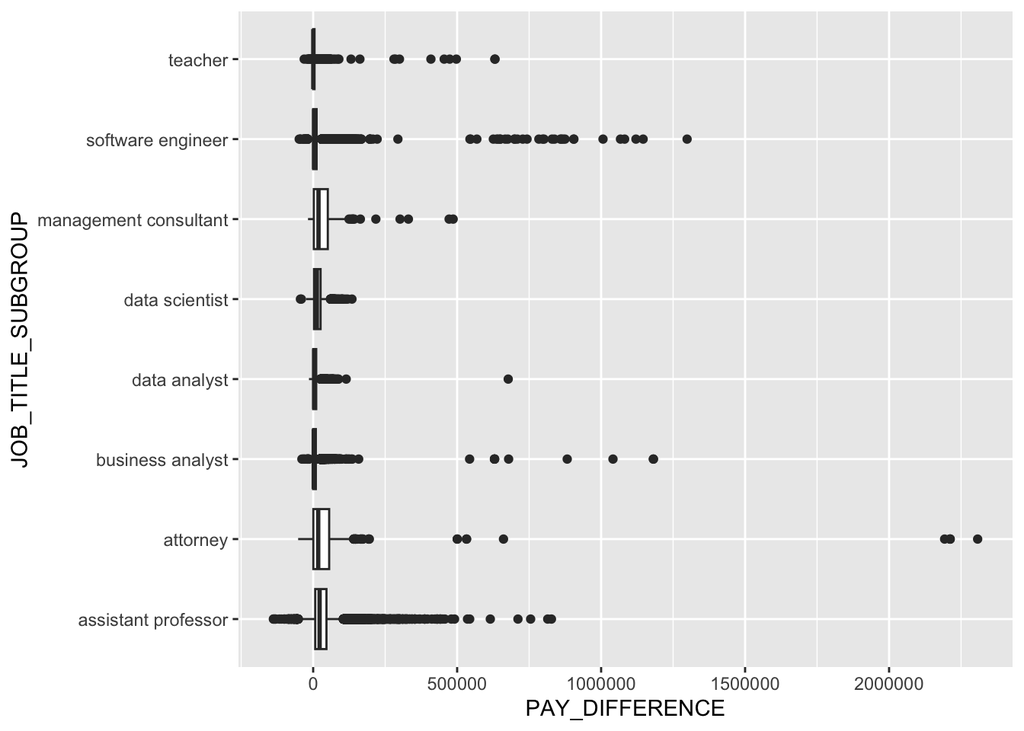

```r
ggplot(data=salary, aes(x=JOB_TITLE_SUBGROUP,
                        y=PAY_DIFFERENCE)) +
  geom_boxplot() +
  coord_flip()
```

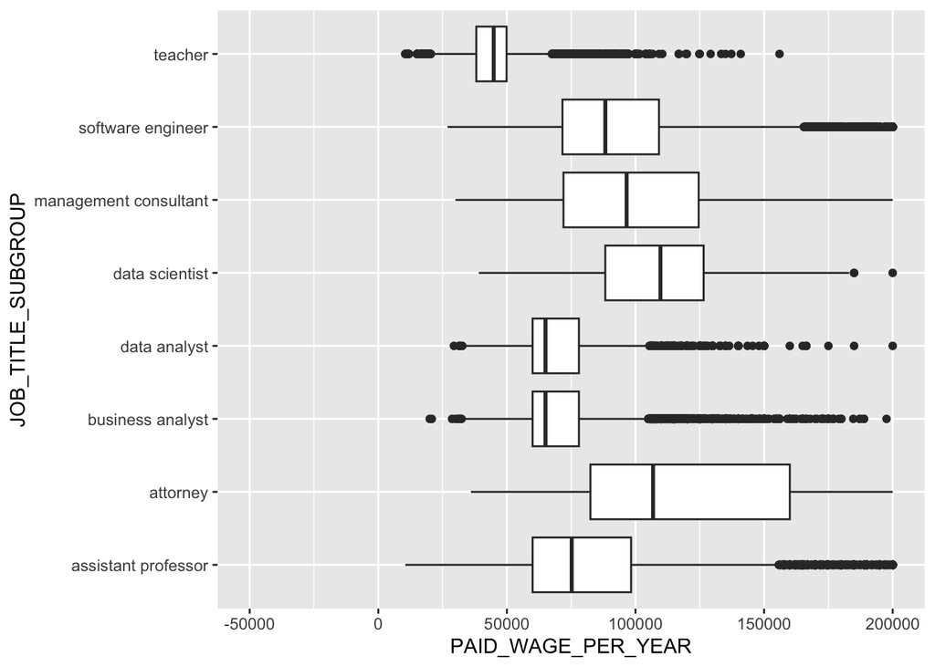

```r
# Paid Wage by job sub-title
ggplot(data=salary, aes(x=JOB_TITLE_SUBGROUP,
                        y=PAID_WAGE_PER_YEAR)) +
  geom_boxplot() +
  coord_flip() +
  ylim(-50000, 200000)
```

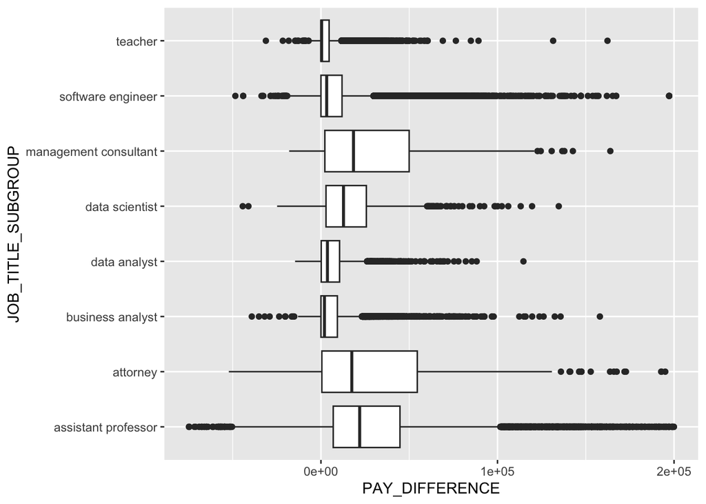

```r
# Difference between paid and prevailing wage
ggplot(data=salary, aes(x=JOB_TITLE_SUBGROUP,
                        y=PAY_DIFFERENCE)) +
  geom_boxplot() +
  coord_flip() +
  ylim(-75000, 200000)
```

```r
# Subset
bus_analyst_subset = subset(salary, JOB_TITLE_SUBGROUP == "business analyst")
summary(bus_analyst_subset$PAID_WAGE_PER_YEAR)
```

```
##    Min. 1st Qu.  Median    Mean 3rd Qu.    Max.
##   20000   60000   65000   71300   78000 1250784
```

- Are there companies that tend to over-pay or under-pay?

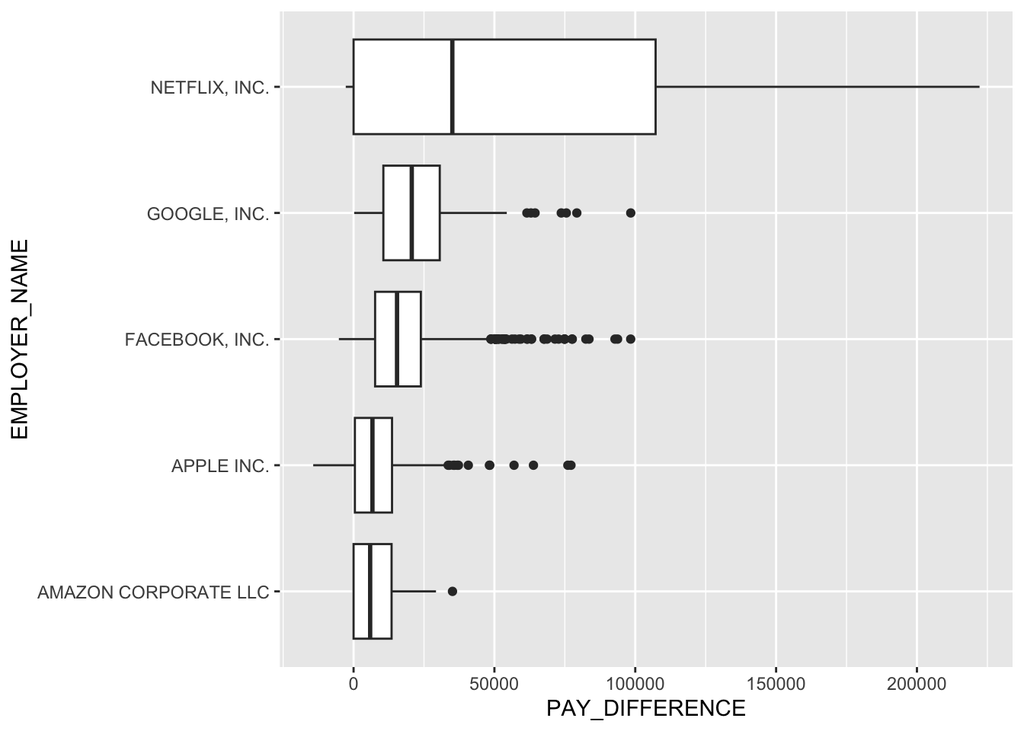

```r
faang_subset = subset(salary,
                      EMPLOYER_NAME == "FACEBOOK, INC." |
                        EMPLOYER_NAME == "APPLE INC." |
                        EMPLOYER_NAME == "AMAZON CORPORATE LLC" |
                        EMPLOYER_NAME == "NETFLIX, INC." |
                        EMPLOYER_NAME == "GOOGLE, INC.")

# Difference between paid and prevailing wage, by employer
ggplot(data=faang_subset, aes(x=EMPLOYER_NAME,
                        y=PAY_DIFFERENCE)) +
  geom_boxplot() +
  coord_flip()
```

- Will the answer change if I take standard of living into account?

## Paid Wage by Required Education Level

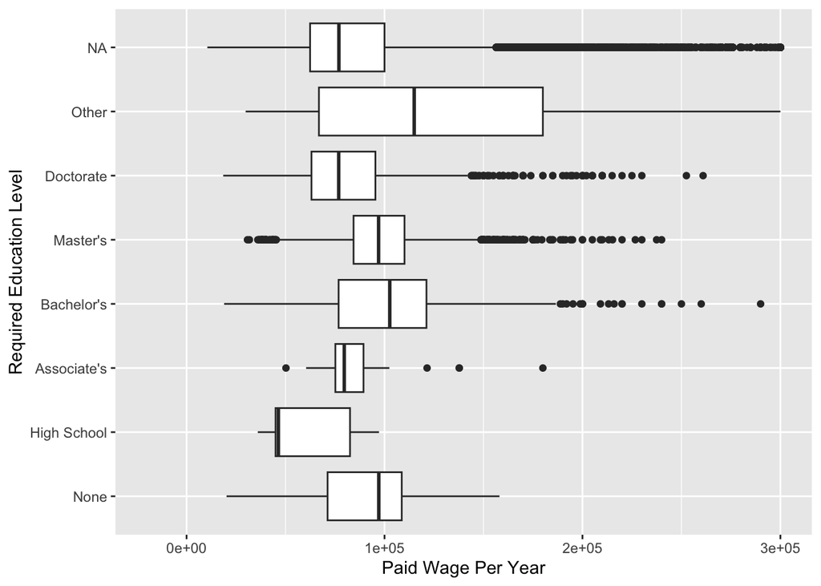

```r
# Create factor variable: equation level required (7 levels)
education = as.factor(salary$EDUCATION_LEVEL_REQUIRED)
education = relevel(factor(education, levels=c("None", "High School",
                                               "Associate's", "Bachelor's",
                                               "Master's", "Doctorate",
                                               "Other")),
                                      ref = "None")

# Plot
ggplot(data=salary, aes(x=education,
                        y=PAID_WAGE_PER_YEAR)) +
  geom_boxplot() +
  coord_flip() +
  ylim(-20000, 300000) +
  xlab("Required Education Level") +
  ylab("Paid Wage Per Year")
```

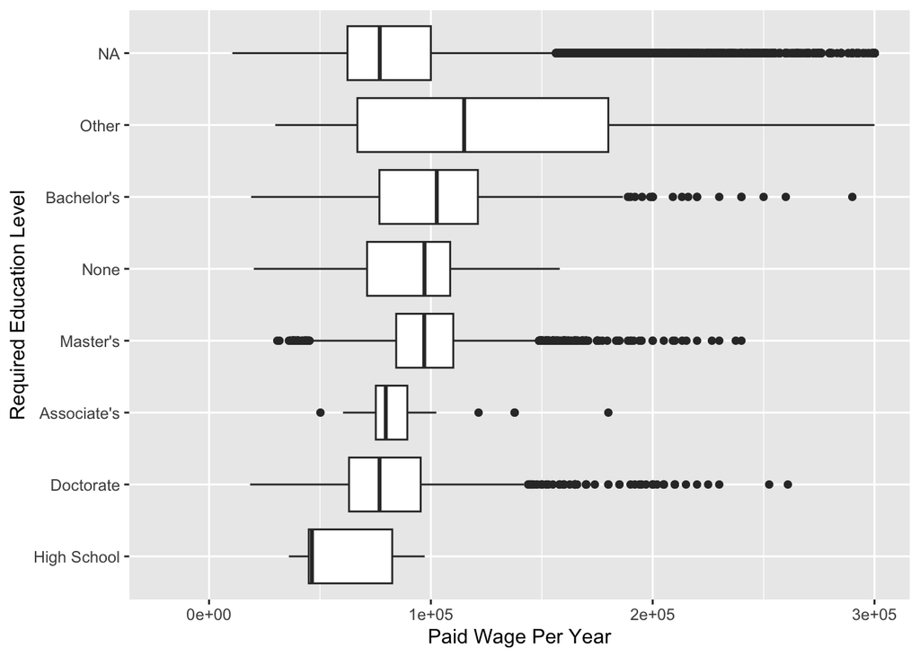

```r
# Ascending Order
ggplot(data=salary, aes(x=reorder(education, PAID_WAGE_PER_YEAR, FUN = median),
                        y=PAID_WAGE_PER_YEAR)) +
  geom_boxplot() +
  coord_flip() +
  ylim(-20000, 300000) +
  xlab("Required Education Level") +
  ylab("Paid Wage Per Year")
```

## How is wage correlated with experience required?

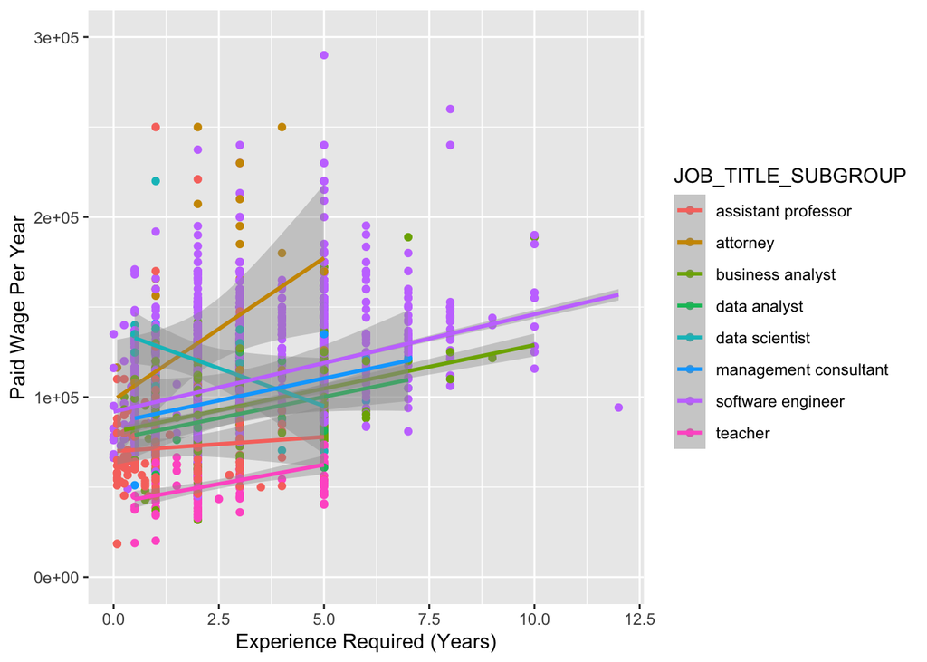

```r
EXPERIENCE_REQUIRED_YEARS = salary$EXPERIENCE_REQUIRED_NUM_MONTHS / 12

# Scatter plot with ggplot2
ggplot(data=salary, aes(x=EXPERIENCE_REQUIRED_YEARS,
                        y=PAID_WAGE_PER_YEAR, color = JOB_TITLE_SUBGROUP)) +
  geom_point() +
  ylab("Paid Wage Per Year") +
  xlab("Experience Required (Years)") +
  ylim(0, 300000) + geom_smooth(method=lm)
```